# Somatic Indels

July 2017

## Outline

- Functional impact of indels in cancer
- Short exercise: exploring TGF-beta receptor 2 indels in COSMIC
- Indel calling tools
- How well do somatic indel callers perform?
- Some characteristics of indels called in HCC1143

## Indels

- Range from 1 to 10,000 bases but here we are mostly considering small indels of 1 - 50 bp
- Lower frequency than SNPs except near highly repetitive regions, including homopolymers and microsatellites

## Somatic frameshift deletion

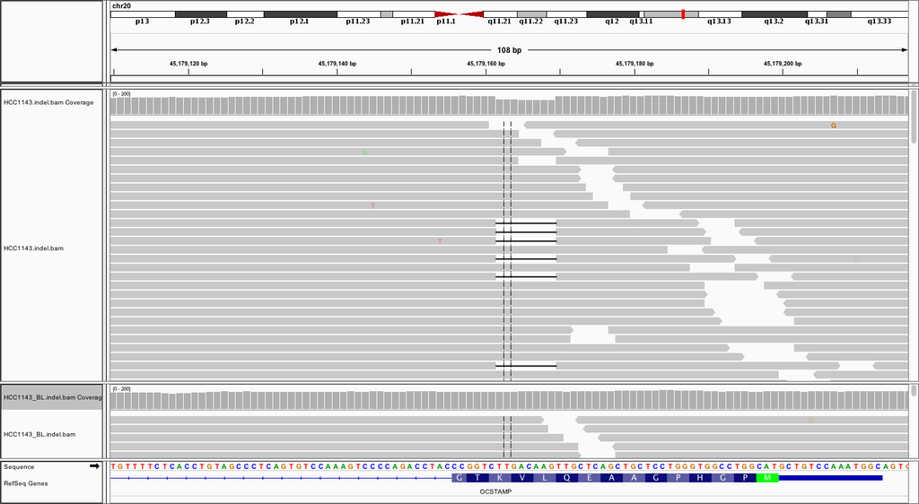

## Functional impact

- 1000 Genomes Project loss of function indel variants in each individual [[Nature 2010](http://www.ncbi.nlm.nih.gov/pubmed/20981092)]
  - 340 - 400 premature stop codons, split site disruptions and frame shifts
  - 250 - 300 genes affected
- Frameshift mutations have an impact in several diseases (cystic fibrosis, HIV, Crohn's disease, Tay-Sachs)
- Colorectal cancer
  - 15% of colorectal tumours characterized by microsatellite instability (MSI), caused by defective mismatch repair
  - DNA slippage within coding sequences induces frameshift mutations resulting in truncated, functionally inactive proteins (TGFBR2 and BAX frequently targeted genes)
- [COSMIC](http://cancer.sanger.ac.uk/cosmic) database of somatic mutations in cancer has several examples of frameshift mutations in tumour suppressors, such as TP53, PTEN, BRCA1/2 and TGFBR2

## Indels in cancer genome sequencing projects

- In-depth analyses in large cohort studies typically focus on substitutions or copy number aberrations/rearrangements
  - Indels often just catalogued
- Recent Sanger Institute paper on 560 breast cancers searched for novel indel drivers in non-coding regions with significant recurrence (functional regulatory elements) [[Nik-Zainal et al., Nature 2016](https://www.ncbi.nlm.nih.gov/pubmed/27135926)]
  - Previously looked at association of indels with mutational signatures [[Nik-Zainal et al., Cell 2012](https://www.ncbi.nlm.nih.gov/pubmed/22608084)]
- Application of 1000 Genomes Project data to cancer genomics showed that genes linked with cancer showed stronger selection against indels [[Science 2013](https://www.ncbi.nlm.nih.gov/pubmed/27135926)]

## Exercise – Exploring indels in TGF-beta receptor 2

- Search for TGFBR2 in the [COSMIC](http://cancer.sanger.ac.uk/cosmic) website
- Explore the breakdown of mutation types for samples with TGFBR2 mutations (Distribution tab)
  - *What proportion of samples have frameshift indels?*
  - *What size are most of these indels?*
- Look at the location of the indels within the gene (Gene View tab)
  - *What is immediately striking about this?*
  - Zoom in on the most frequently observed indel and turn on the DNA sequence display
  - *What is the sequence context at this indel?*
- Click on the c.374delA deletion to access details of the cancers in which this mutation was observed
  - *Which cancer type is this mutation most commonly seen in?*

## Indel calling tools

- Several tools call both SNVs and indels particularly those tools that perform local reassembly or realignment around likely indel sites
  - VarScan2
  - Strelka
  - MuTect2
  - VarDict
- **Pindel** is the somatic indel caller used in the Sanger CGP pipeline
  - Uses a pattern growth algorithm for unmapped paired end reads anchored to mapped mate
  - Can identity short and medium sized indels up to 10kb
  - Modified version used in CGP pipeline that takes advantage of additional alignment information available for longer reads (>100 bases) and can make use of split read alignments

## Identifying indels can be tricky

- Many indels exist in long homopolymers and short sequence repeats (di-nucleotides, tri-nucleotides, etc.)
- Not easy to distinguish between true variants caused by replication slippage and sequencing errors
  - Strelka filters out indels within repeats above certain length
- Homopolymer A/T indels are major source of low quality indel calls [[Fang et al., Genome Med. 2014](https://www.ncbi.nlm.nih.gov/pubmed/25426171)]
- Benchmark exercises show that indels are harder to call accurately that SNVs
  - ICGC medulloblastoma benchmark study [[Alioto et al., Nat Commun. 2015](http://www.ncbi.nlm.nih.gov/pubmed/26647970)]

## ICGC MB99 benchmark

[interactive chart not shown]

## Indels in HCC1143

[interactive chart not shown]

Total of 208 somatic insertions and 564 somatic deletions called by Pindel.

## Short sequence repeat expansions/contractions in HCC1143

[interactive chart not shown]

272 hompolymer A/T indels (35% of all indels), almost all of which are 1-bp insertions or deletions.